# 🏎️ Nina's F1 Predictions: 2026 Canada Grand Prix (Round 5)

## Circuit Gilles Villeneuve — May 22-24, 2026

**Model version:** v1.0+Q (retrospective) **Confidence:** HIGH

### What This Is

A machine learning model that predicts Formula 1 race results from 24 features — the same kinds of data a race engineer considers when building race strategy. The model trains on every race through the round before this one (2026 weighted 10x over 2023-2025 history), takes the **actual qualifying grid** and **live qualifying sector times** for this weekend, then runs 10,000 simulated races to estimate podium probabilities.

> **This is a reconstructed prediction.** The model was rebuilt using only data available before the Canada GP — nothing from the race itself enters the model — so the accuracy check in the final section is a fair test. It backfills the season scoreboard for a race weekend that ran before the model was caught up.

```
============================================================
  🤖 XGBOOST v1.0 — 24 features, trained through Round 4
============================================================
  Training rows: 1,485
  Leave-one-out MAE: 2.33 positions (honest)
  Residual StdDev:   2.90

  Top features:
    grid_position             0.237
    team_pit_strategy         0.151
    car_pace                  0.064
    car_speed                 0.060
    driver_avg_finish         0.055
    sector2_delta             0.047
    quali_race_gap            0.036
    consistency               0.032
```

## 1. Qualifying & Blended Car Pace

Grid position is the model's single strongest predictor. This weekend's actual qualifying result sets the starting grid, and the team-level pace is a 30/70 blend of season-to-date form and qualifying performance. Live Canada sector deltas from qualifying replace the historical track profile.

```
======================================================================
  🏁 QUALIFYING GRID — 2026 Canada GP
======================================================================

  Pos  Driver                  Team                Blend Pace
  ------------------------------------------------------------
  P 1  George Russell          Mercedes            P   1.6
  P 2  Kimi Antonelli          Mercedes            P   1.6
  P 3  Lando Norris            McLaren             P   5.3
  P 4  Oscar Piastri           McLaren             P   5.3
  P 5  Lewis Hamilton          Ferrari             P   5.9
  P 6  Max Verstappen          Red Bull Racing     P   8.2
  P 7  Isack Hadjar            Red Bull Racing     P   8.2
  P 8  Charles Leclerc         Ferrari             P   5.9
  P 9  Arvid Lindblad          Racing Bulls        P  11.0
  P10  Franco Colapinto        Alpine              P  11.8
  P11  Nico Hulkenberg         Audi                P  12.8
  P12  Liam Lawson             Racing Bulls        P  11.0
  P13  Gabriel Bortoleto       Audi                P  12.8
  P14  Pierre Gasly            Alpine              P  11.8
  P15  Carlos Sainz            Williams            P  15.8
  P16  Oliver Bearman          Haas F1 Team        P  15.0
  P17  Esteban Ocon            Haas F1 Team        P  15.0
  P18  Alexander Albon         Williams            P  15.8
  P19  Fernando Alonso         Aston Martin        P  19.3
  P20  Sergio Perez            Cadillac            P  19.7
  P21  Lance Stroll            Aston Martin        P  19.3
  P22  Valtteri Bottas         Cadillac            P  19.7

  🌡️ Race conditions: 12.8°C, 72% humidity, DRY
```

## 2. Predicted Finish

Each driver's predicted finishing position, with the inputs that drove it: grid (actual qualifying), car (blended team pace), and the position change the model expects relative to the grid.

```
================================================================================
  🏁 PREDICTED FINISH — 2026 Canada GP
================================================================================

  Pos  Driver                  Team                Grid   Pred  ΔGrid
  ----------------------------------------------------------------------
  P 1  Kimi Antonelli          Mercedes            P 2  P 1.9     +1
  P 2  George Russell          Mercedes            P 1  P 1.9     -1
  P 3  Lando Norris            McLaren             P 3  P 3.8      =
  P 4  Lewis Hamilton          Ferrari             P 5  P 4.4     +1
  P 5  Oscar Piastri           McLaren             P 4  P 4.6     -1
  P 6  Max Verstappen          Red Bull Racing     P 6  P 5.6      =
  P 7  Charles Leclerc         Ferrari             P 8  P 6.9     +1
  P 8  Isack Hadjar            Red Bull Racing     P 7  P 7.8     -1
  P 9  Franco Colapinto        Alpine              P10  P 9.1     +1
  P10  Nico Hulkenberg         Audi                P11  P 9.1     +1
  P11  Gabriel Bortoleto       Audi                P13  P 9.2     +2
  P12  Arvid Lindblad          Racing Bulls        P 9  P 9.5     -3
  P13  Liam Lawson             Racing Bulls        P12  P10.8     -1
  P14  Oliver Bearman          Haas F1 Team        P16  P11.5     +2
  P15  Pierre Gasly            Alpine              P14  P12.4     -1
  P16  Carlos Sainz            Williams            P15  P13.1     -1
  P17  Esteban Ocon            Haas F1 Team        P17  P14.2      =
  P18  Alexander Albon         Williams            P18  P15.0      =
  P19  Fernando Alonso         Aston Martin        P19  P15.1      =
  P20  Valtteri Bottas         Cadillac            P22  P16.0     +2
  P21  Sergio Perez            Cadillac            P20  P16.6     -1
  P22  Lance Stroll            Aston Martin        P21  P17.4     -1
```

## 3. Podium Probabilities (10,000 Simulated Races)

Rather than a single outcome, the model simulates the race 10,000 times with realistic randomness — and now models **retirements**: each driver can DNF with their season failure rate, which promotes everyone behind them. That matters most at high-attrition tracks, where a front-runner's mechanical failure reshuffles the order. Add a 33% safety-car chance and grid-dependent chaos (the midfield is messier than the front row), and the result is a probability for each driver.

```
  Modeled retirements: 3.9 per race (driven by each driver's season DNF rate)

================================================================================
  🎲 PODIUM PROBABILITIES — 2026 Canada GP
================================================================================

  Driver                  Team                Grid     Win   Podium    Top5
  ------------------------------------------------------------------------
  Kimi Antonelli          Mercedes            P 2   33.2%    76.4%   92.9%  ████████████████
  George Russell          Mercedes            P 1   33.1%    76.6%   92.5%  ████████████████
  Lewis Hamilton          Ferrari             P 5    8.4%    32.4%   60.5%  ████
  Lando Norris            McLaren             P 3    6.5%    32.0%   60.1%  ███
  Oscar Piastri           McLaren             P 4    5.5%    21.9%   42.4%  ██
  Charles Leclerc         Ferrari             P 8    4.7%    15.4%   32.2%  ██
  Max Verstappen          Red Bull Racing     P 6    4.2%    20.2%   44.9%  ██
  Franco Colapinto        Alpine              P10    1.2%     6.3%   16.2%
  Arvid Lindblad          Racing Bulls        P 9    1.0%     4.7%   13.6%
  Gabriel Bortoleto       Audi                P13    0.7%     3.9%   10.2%
  Nico Hulkenberg         Audi                P11    0.6%     3.3%    9.0%
  Isack Hadjar            Red Bull Racing     P 7    0.5%     4.1%   14.3%
```

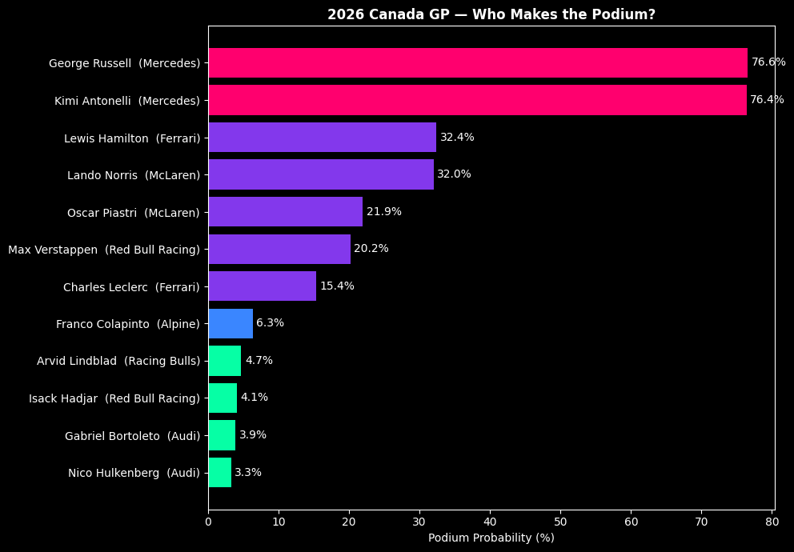

## 4. Race Results & Model Accuracy

The race has run — time to grade the model. Predicted order against the official classification: position-by-position error, podium / top-5 / top-10 accuracy, and the standout calls and misses. These numbers feed the season scoreboard.

```
=====================================================================================
  🏁 OFFICIAL RESULTS vs MODEL — 2026 Canada GP
=====================================================================================

  Fin  Driver                  Team                Pred   Err  Status
  ------------------------------------------------------------------------------
  P 1  Kimi Antonelli          Mercedes            P 1     0  Finished 🎯
  P 2  Lewis Hamilton          Ferrari             P 4     2  Finished
  P 3  Max Verstappen          Red Bull Racing     P 6     3  Finished
  P 4  Charles Leclerc         Ferrari             P 7     3  Finished
  P 5  Isack Hadjar            Red Bull Racing     P 8     3  Lapped
  P 6  Franco Colapinto        Alpine              P 9     3  Lapped
  P 7  Liam Lawson             Racing Bulls        P13     6  Lapped
  P 8  Pierre Gasly            Alpine              P15     7  Lapped
  P 9  Carlos Sainz            Williams            P16     7  Lapped
  P10  Oliver Bearman          Haas F1 Team        P14     4  Lapped
  P11  Oscar Piastri           McLaren             P 5     6  Lapped
  P12  Nico Hulkenberg         Audi                P10     2  Lapped
  P13  Gabriel Bortoleto       Audi                P11     2  Lapped
  P14  Esteban Ocon            Haas F1 Team        P17     3  Lapped
  P15  Lance Stroll            Aston Martin        P22     7  Lapped
  P16  Valtteri Bottas         Cadillac            P20     4  Lapped
  P17  Sergio Perez            Cadillac            P21   DNF  Retired
  P18  Lando Norris            McLaren             P 3   DNF  Retired
  P19  George Russell          Mercedes            P 2   DNF  Retired
  P20  Fernando Alonso         Aston Martin        P19   DNF  Retired
  P21  Alexander Albon         Williams            P18   DNF  Retired
  P22  Arvid Lindblad          Racing Bulls        P12   DNF  Did not start

  📊 SCORECARD
  ------------------------------------------------------------
  Predicted winner:  Kimi Antonelli
  Actual winner:     Kimi Antonelli  ✅
  Podium accuracy:   1/3
  Top 5 accuracy:    2/5   (grid baseline: 2/5)
  Top 10 accuracy:   6/10  (grid baseline: 6/10)
  MAE (classified):  3.88 positions  (validation expected 2.33)

  🏁 vs GRID BASELINE (does the model beat 'finish = qualifying order'?)
  Grid-copy MAE:     3.94 positions
  Model edge:        +0.06  ->  model beats grid

  🎯 Best calls:   Kimi Antonelli (P1→P1), Lewis Hamilton (P4→P2), Nico Hulkenberg (P10→P12)
  💥 Worst misses: Pierre Gasly (pred P15, fin P8), Carlos Sainz (pred P16, fin P9), Lance Stroll (pred P22, fin P15)
  🔧 DNFs: Sergio Perez, Lando Norris, George Russell, Fernando Alonso, Alexander Albon, Arvid Lindblad
```

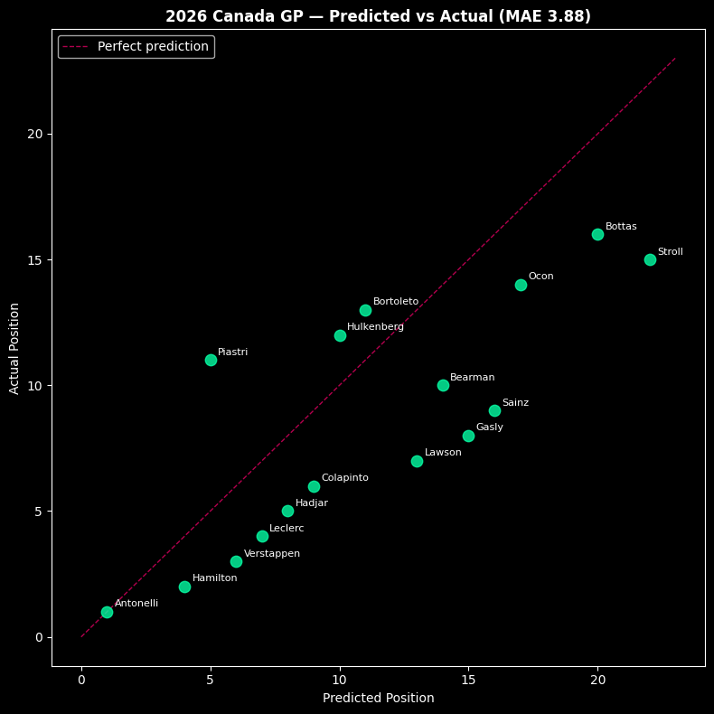